# 5-TimeSeries2

Carson Batchelor

2025-03-10

Utilize the time series data of air-carrier freight for the analysis by following these steps:

```r
rm(list=ls())
air = ts(scan("../../data/AirFreight.txt"), start=c(1969,1), end=c(1978,12), frequency=12)
air
```

```
##       Jan  Feb  Mar  Apr  May  Jun  Jul  Aug  Sep  Oct  Nov  Dec
## 1969 1299 1148 1345 1363 1374 1533 1592 1687 1384 1388 1295 1489
## 1970 1403 1243 1466 1434 1520 1689 1763 1834 1494 1439 1327 1554
## 1971 1405 1252 1424 1517 1483 1605 1775 1840 1573 1617 1485 1710
## 1972 1563 1439 1669 1651 1654 1847 1931 2034 1705 1725 1687 1842
## 1973 1696 1534 1814 1796 1822 2008 2088 2230 1843 1848 1736 1826
## 1974 1766 1636 1921 1882 1910 2034 2047 2195 1765 1818 1634 1818
## 1975 1698 1520 1820 1689 1775 1968 2110 2241 1803 1899 1762 1901
## 1976 1839 1727 1954 1991 1988 2146 2301 2338 1947 1990 1832 2066
## 1977 1952 1747 2098 2057 2060 2240 2425 2515 2128 2255 2116 2315
## 1978 2143 1948 1460 2344 2363 2630 2811 2972 2515 2536 2414 2545
```

Step 1. Display the time series plot along with the corresponding ACF and PACF plots. a) Does the data exhibit a non-seasonal trend? b) Does the data exhibit a seasonality?

- Yes, the data exhibits an upward non-seasonal trend, as seen in the general increase in freight volume over time.
- Yes, the data exhibits seasonality with a period of 12 months, as seen in the repeating patterns within each year. in the acf() and pacf() plots, there are significant spikes at lags 0.0,1.0,2.0.

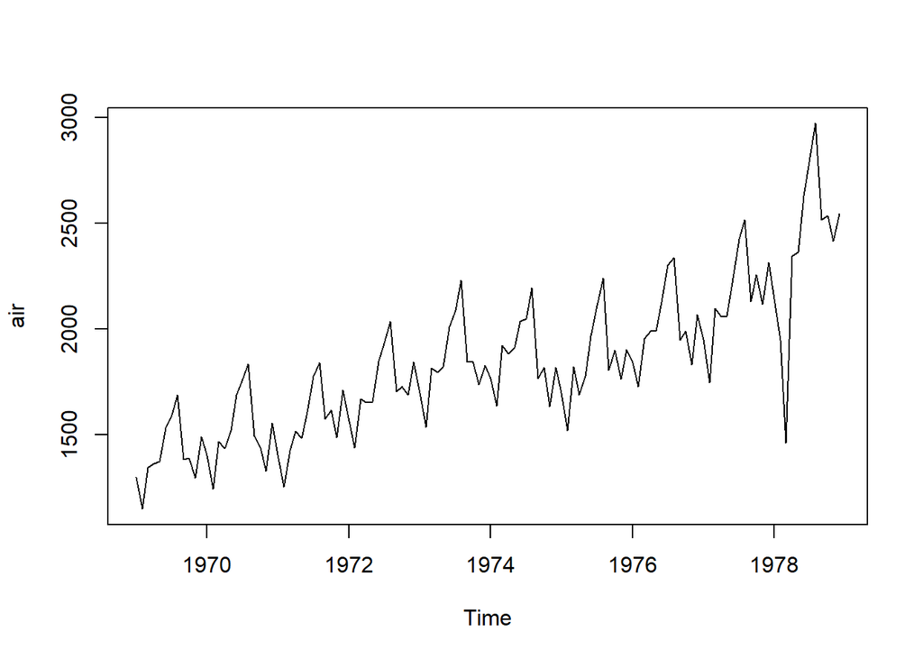

```r
# Time Series plot
ts.plot(air)
```

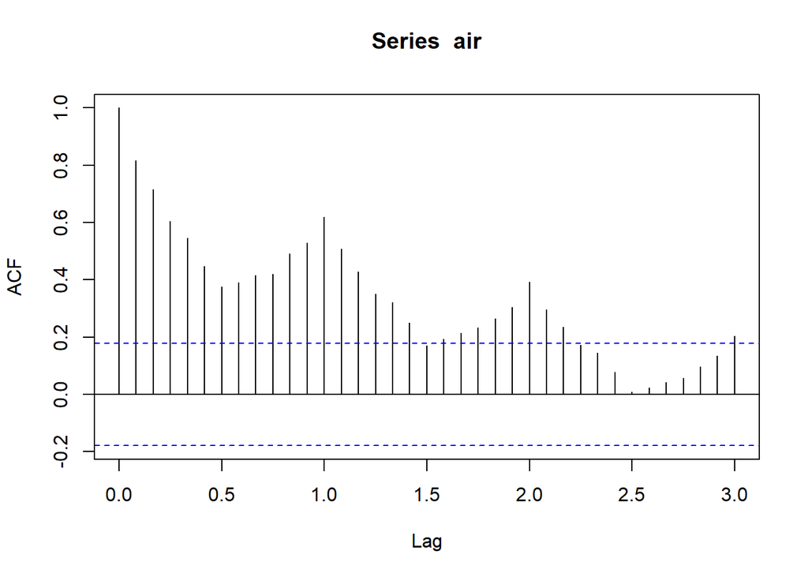

```r
# Auto Correlation and Partial Correlation Plots
acf(air, lag.max=36)
```

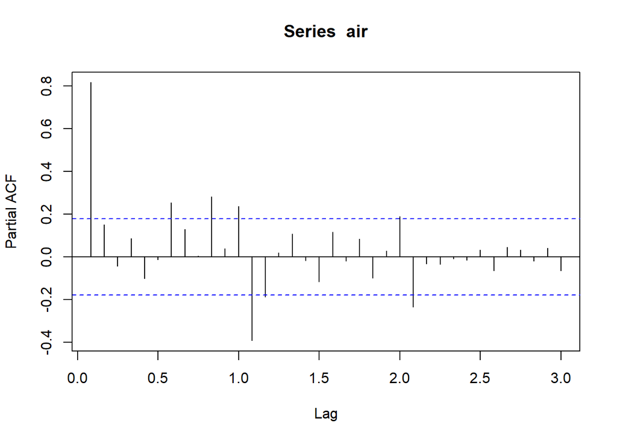

```r
pacf(air, lag.max=36)
```

Step 2. If your answer to 1-a) is No, skip this question. If your answer to 1-a) is Yes, propose a differencing method to remove the trend from the data. Provide the time series plot of the detrended data along with the corresponding ACF and PACF plots.

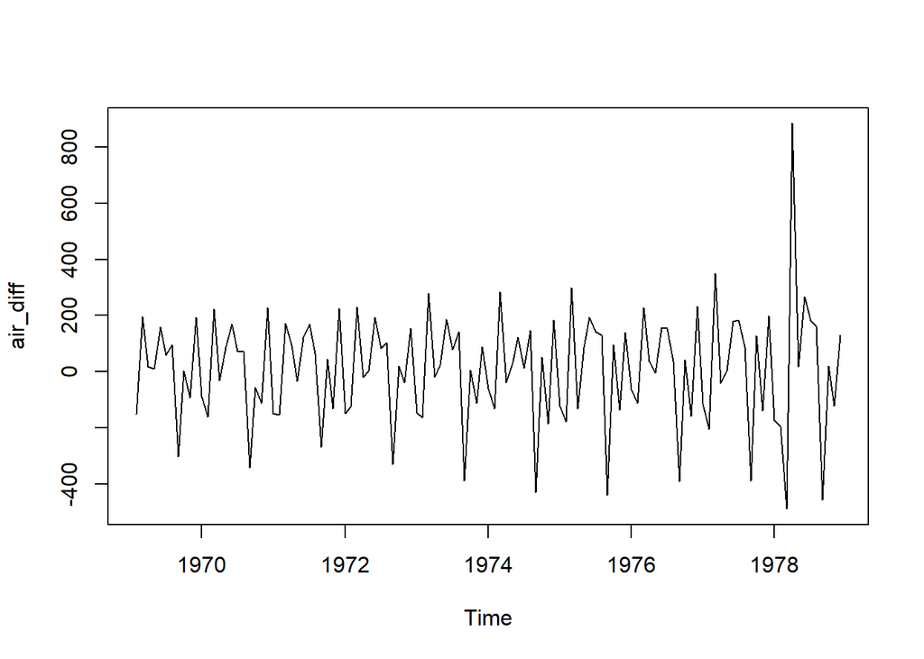

```r
# first difference
air_diff <- diff(air, lag=1)

# First Difference Time Series plot
ts.plot(air_diff)
```

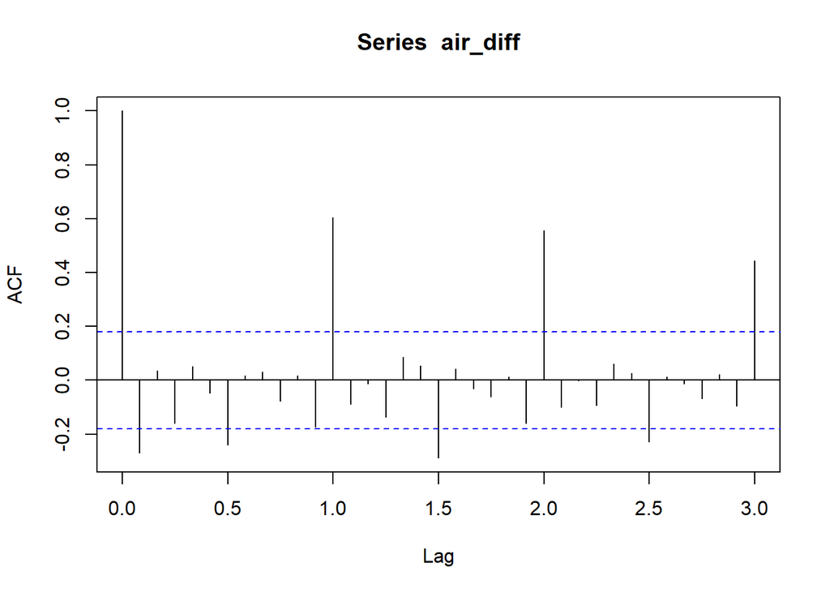

```r
# First Difference Auto Correlation and Partial Correlation Plots
acf(air_diff, lag.max=36)
```

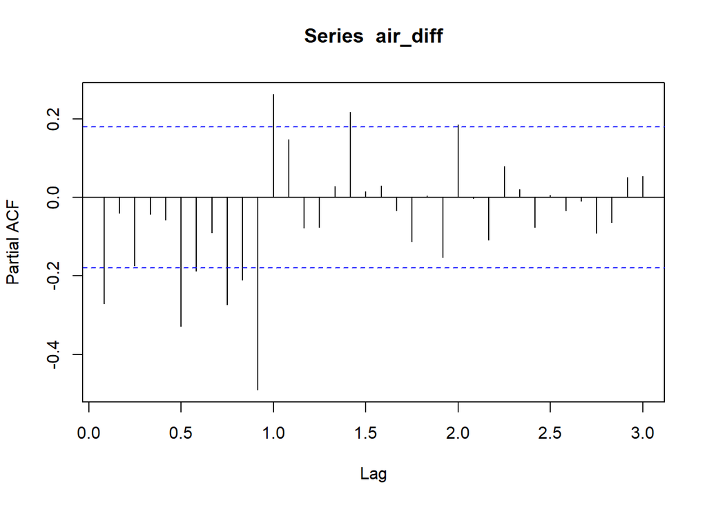

```r
pacf(air_diff, lag.max=36)
```

Step 3. If your answer to 1-b) is No, skip this question. If your answer to 1-b) is Yes, propose a differencing method to further eliminate seasonality. Provide the time series plot of the data with both trend (if applicable) and seasonality removed, along with the corresponding ACF and PACF plots.

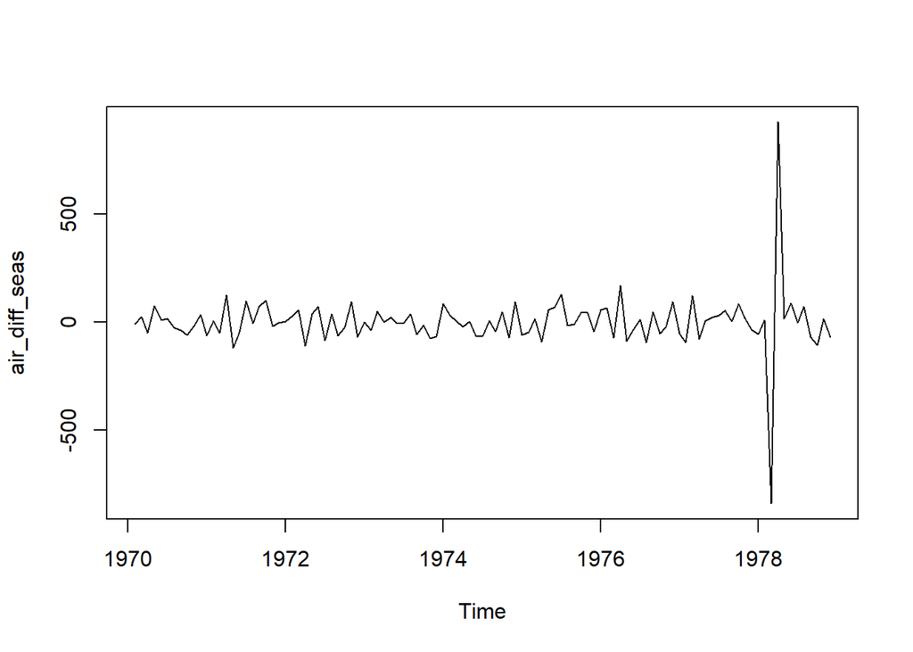

```r
# Seasonal differencing to remove seasonality
air_diff_seas <- diff(air_diff, lag=12)

# Time series plot of data with trend and seasonality removed
ts.plot(air_diff_seas)
```

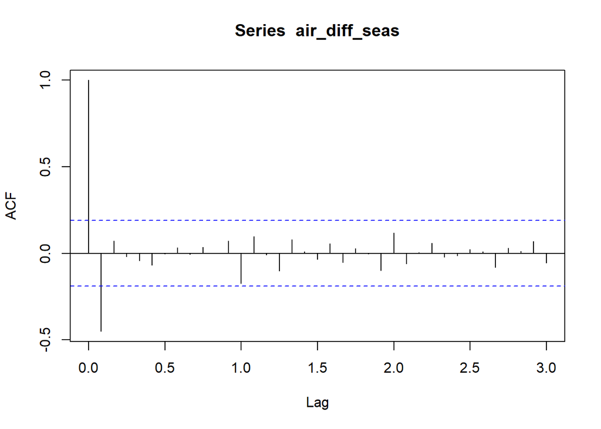

```r
# ACF and PACF plots
acf(air_diff_seas, lag.max=36)
```

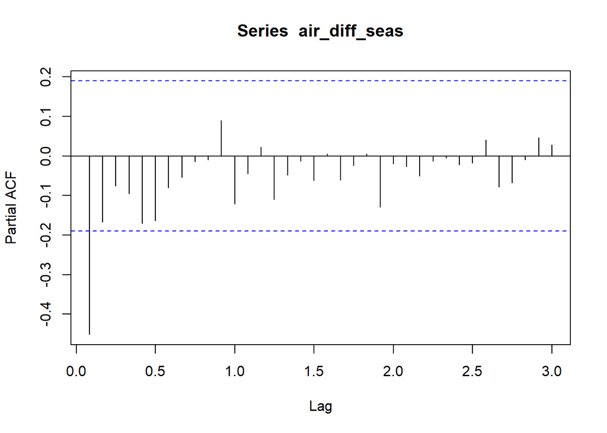

```r
pacf(air_diff_seas, lag.max=36)
```

Step 4. Based on the analysis in steps 2 and 3, use auto.arima to assist model development. Fit and report your final model.

```r
library(forecast)
# Use auto.arima to select the best SARIMA model
final_model <- auto.arima(air_diff_seas, seasonal=TRUE)

# Report the final model
summary(final_model)
```

```
## Series: air_diff_seas
## ARIMA(0,0,1)(1,0,0)[12] with zero mean
##
## Coefficients:
##           ma1     sar1
##       -0.5924  -0.4785
## s.e.   0.0979   0.1412
##
## sigma^2 = 12347:  log likelihood = -656.62
## AIC=1319.25   AICc=1319.48   BIC=1327.27
##
## Training set error measures:
##                   ME     RMSE     MAE  MPE MAPE      MASE       ACF1
## Training set 5.94397 110.0724 59.3044 -Inf  Inf 0.5778971 0.02854468
```

Step 5. Show the ACF and PACF plots of the residuals from your final model. Assess whether these plots suggest stationarity in the residuals.

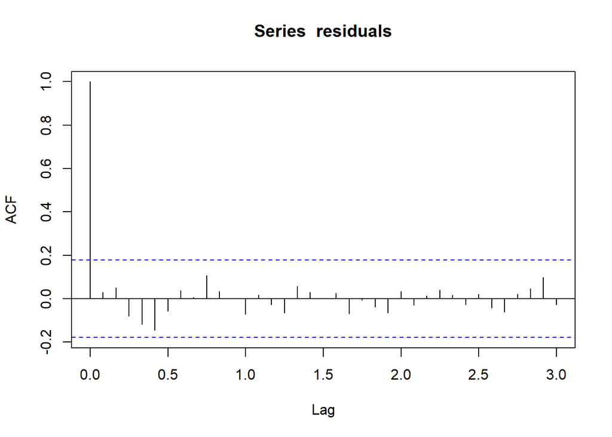

```r
# train best model on raw data
best_model <- Arima(air, order = c(0,1,1), seasonal = c(0,1,1), include.constant = TRUE)
# Extract residuals
residuals <- residuals(best_model)

# ACF and PACF plots of residuals
acf(residuals, lag.max=36)
```

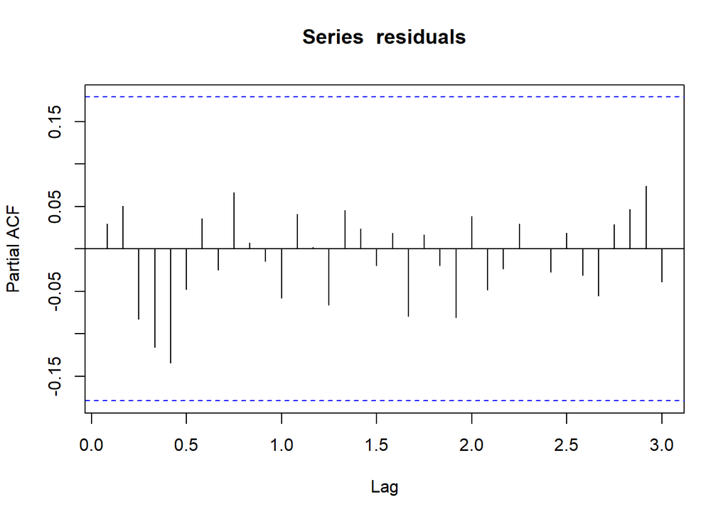

```r
pacf(residuals, lag.max=36)
```

Step 6. Utilize the final model to generate 36-month ahead forecasts for air-carrier freight. Plot both the forecasts and the forecast intervals.

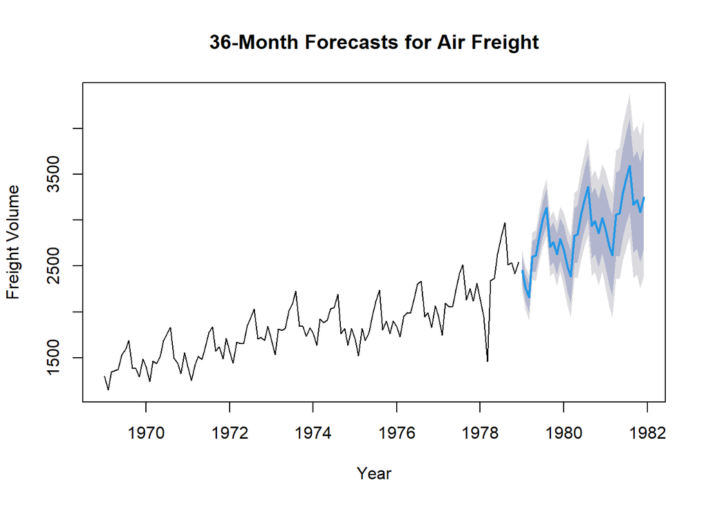

```r
# Generate 36-month ahead forecasts
forecasts <- forecast(best_model, h=36)

# Plot the forecasts with forecast intervals
plot(forecasts, main="36-Month Forecasts for Air Freight", ylab="Freight Volume", xlab="Year")
```